#CABIN VERIFICATION AND VALIDATION - GENERAL DATA

*Environment and Climate Change Canada*

*Analysis performed on 2019-08-13 13:54:59*

This report presents the results for verification and validation of a general CABIN data file associated to the project **Test**.

In this analysis, the general dataset is checked to answer the following question:

- Do the general data reflect the sites visited?

This document is a R notebook written in [R Markdown](http://rmarkdown.rstudio.com). When you execute the code embedded in the notebook, the results will appear under the corresponding code. To do this, place your cursor inside a chunk (box which contains *R* code) and click the green arrow to the right of it named *Run Current Chunk* or press *Ctrl+Shift+Enter* (*Cmd+Shift+Enter* in *macOS*) on your keyboard. Repeat for each chunk. As the code contained in this notebook is executed, the results will appear under each of the corresponding chunks in this window. Once all commands are executed, click the *Preview* button at the top left of this window or press the *Ctrl+Shift+K* keys (*Cmd+Shift+K* in *macOS*). A new window will appear and will contain the report of these verification and validation results for the general CABIN data.

##Requirements

This notebook assumes that you have imported your data into *R* using the import notebook (CABIN_vv_import.Rmd).

The dataset containing general data for this project is **present**.

##Descriptive Statistics

The data file contains 448 visits (lines) and 27 variables (columns).

The following table presents a subset of the data.

**Reading General Data**

| SampleId | Taxonomist | Study | Site | SampleDate | Year | JulianDay | Name | Basin | KywId | KywName | EcoregionNumber | Ecoregion | Province | EnvirodatId | Description | Device | SampleNumber | SampleStatus | Latitude | Longitude | GPSDatum | Altitude | StreamOrder | DistanceFromSource | SubSample | TotalSample |
| --- | --- | --- | --- | --- | --- | --- | --- | --- | --- | --- | --- | --- | --- | --- | --- | --- | --- | --- | --- | --- | --- | --- | --- | --- | --- | --- |
| 17215 | Heather McDermott | CABIN Training Module | AA06221 | 2008-09-30 | 2008 | 274 | Coldwater River | Coldwater River | 08L04 | Thompson | 209 | Thompson-Okanagan Plateau | British Columbia |  | North of Coquihalla Hwy, access via Kingsvale, bridge ~50m u/s | Kick Net | 1 | Test | 49.905 | -120.9155556 | nad83 | 2719 | 3 |  | 17 | 100 |
| 17216 | Heather McDermott | CABIN Training Module | AA06222 | 2008-09-29 | 2008 | 273 | Fraser River | Fraser River | 08M01 | Lower Fraser | 192 | Pacific Ranges | British Columbia |  | Access via Bulgur Rd before reserve, d/s of the town of Hope | Kick Net | 1 | Test | 49.3475 | -121.6055556 | nad83 | 25 | 8 |  | 46 | 100 |
| 17217 | Heather McDermott | CABIN Training Module | AA06223 | 2008-09-28 | 2008 | 272 | Quinsam River | Quinsam River | 08H07 | East Central Vancouver Island | 194 | Eastern Vancouver Island | British Columbia |  | At Elk Falls Provincial Park; u/s of confluence with Campbell River, access at campsite #2 | Kick Net | 1 | Test | 50.0366667 | -125.295 | nad83 | 16 | 3 |  | 40 | 100 |
| 18368 | Heather McDermott | CABIN Training Module | AA09211 | 2008-09-30 | 2008 | 274 | Coldwater River | Coldwater River | 08L04 | Thompson | 209 | Thompson-Okanagan Plateau | British Columbia |  | North of Coquihalla; access via Kingsvale Bridge about 50 m upstream. | Kick Net | 1 | Test | 49.905 | -120.9155556 | nad83 | 2716 | 3 |  | 17 | 100 |
| 18375 | Heather McDermott | CABIN Training Module | AA09212 | 2008-09-29 | 2008 | 273 | Fraser River | Fraser River | 08M01 | Lower Fraser | 192 | Pacific Ranges | British Columbia |  | Access via Bulgur Road before reserve;downstream of the town of Hope | Kick Net | 1 | Test | 49.3475 | -121.6055556 | nad83 | 25 | 8 |  | 46 | 100 |
| 18364 | Heather McDermott | CABIN Training Module | AA09213 | 2008-09-28 | 2008 | 272 | Quinsam River | Quinsam River | 08H07 | East Central Vancouver Island | 194 | Eastern Vancouver Island | British Columbia |  | @ Elk Falls Provincial Park; upstream of confluence with Campbell River; access from Campsite #2. | Kick Net | 1 | Test | 50.0366667 | -125.295 | nad83 | 16 | 3 |  | 4 | 100 |
| 18493 | Heather McDermott | CABIN Training Module | AB02061 | 2008-09-30 | 2008 | 274 | Coldwater River | Coldwater River | 08L04 | Thompson | 209 | Thompson-Okanagan Plateau | British Columbia |  | North of coquihalla hwy; access via kingsvale bridge approximately 50km upstream | Kick Net | 1 | Test | 49.905 | -120.9155556 | nad83 | 2716 | 3 |  | 17 | 100 |
| 18495 | Heather McDermott | CABIN Training Module | AB02062 | 2008-09-29 | 2008 | 273 | Fraser River | Fraser River | 08M01 | Lower Fraser | 192 | Pacific Ranges | British Columbia |  | Access via Bulgur Rd before reserve; d/s of the town of Hope | Kick Net | 1 | Test | 49.3475 | -121.6055556 | nad83 | 25 | 8 |  | 46 | 100 |
| 18496 | Heather McDermott | CABIN Training Module | AB02063 | 2008-09-28 | 2008 | 272 | Quinsam River | Quinsam River | 08H07 | East Central Vancouver Island | 194 | Eastern Vancouver Island | British Columbia |  | At Elk Falls Provincial Park, upstream of confluence with Campbell River; Access from campsite #2 | Kick Net | 1 | Test | 50.0366667 | -125.295 | nad83 | 16 | 3 |  | 4 | 100 |
| 18758 | Heather McDermott | CABIN Training Module | AB05291 | 2008-09-30 | 2008 | 274 | Coldwater River | Coldwater River | 08L04 | Thompson | 209 | Thompson-Okanagan Plateau | British Columbia |  | Site 1, North of Coquihalla Hwy; access via Kingsvale Bridge ~50m upstream (CABIN training module);Water chemistry comment: Nitrate &lt;0.002 mg/L, Nitrite &lt;0.005 mg/L | Kick Net | 1 | Test | 49.905 | -120.9155556 | nad83 | 2716 | 3 |  | 17 | 100 |

[output cut: 438 more lines]

> *Check the data and make sure it reflects reality. Consider the following:*
> - *Does the file seem to have been read correctly?*
> - *Are columns missing?*

**List of visits present in the general data (ID from the CABIN database):**

17215, 17216, 17217, 18368, 18375, 18364, 18493, 18495, 18496, 18758, 18759, 18760, 18546, 18548, 18549, 19013, 19017, 19018, 16962, 16965, 16966, 17363, 17364, 17365, 18839, 18841, 18845, 17492, 17493, 17494, 21911, 21925, 21926, 18328, 18329, 18330, 19971, 20219, 18632, 20220, 18628, 18630, 18631, 17496, 17497, 17498, 18889, 18890, 18892, 20302, 20303, 20304, 18663, 18664, 18665, 16863, 18796, 18798, 18799, 19070, 19072, 19082, 18718, 18723, 18724, 17241, 17248, 17253, 18693, 18826, 19044, 17272, 17273, 17274, 18787, 18790, 18791, 17522, 17568, 17573, 17436, 17437, 17438, 18378, 18449, 18459, 24059, 17450, 17456, 17461, 18747, 18748, 18750, 18730, 18732, 18734, 16913, 16914, 16919, 18300, 18301, 18302, 18499, 18498, 18497, 16921, 16922, 16923, 18296, 18298, 18299, 16849, 16853, 16854, 17412, 17413, 17418, 18545, 18735, 18736, 18667, 18678, 18692, 18666, 18681, 18682, 17502, 17565, 17570, 18622, 18623, 18624, 18821, 18823, 18824, 19037, 19042, 19043, 18542, 18543, 18544, 17443, 17444, 18901, 18903, 18904, 21846, 21850, 21854, 19045, 19046, 19048, 18331, 18332, 18333, 19038, 19040, 19041, 19069, 19073, 19084, 18757, 18830, 18832, 18610, 18611, 18616, 17472, 17476, 17477, 19086, 19087, 19088, 18891, 18893, 18899, 18753, 18777, 18780, 17463, 17465, 17466, 18828, 18829, 18894, 18803, 18805, 18806, 17488, 17490, 17491, 17569, 17575, 17578, 18922, 18977, 18996, 18923, 18927, 18929, 18482, 18483, 18484, 19015, 19016, 19014, 16934, 16935, 16936, 28210, 28212, 28213, 29505, 29506, 29507, 19033, 19035, 19036, 19075, 19077, 19078, 18475, 18479, 18480, 18453, 18454, 18455, 19094, 19096, 19098, 16907, 16908, 16911, 18661, 18662, 18782, 18743, 18770, 18774, 18711, 18716, 18717, 16867, 16868, 16866, 18695, 18696, 18766, 18655, 18658, 18659, 18763, 18768, 18769, 18520, 18524, 18525, 17483, 17487, 17489, 18772, 18773, 18775, 16945, 16961, 16967, 18644, 18669, 18677, 16834, 18310, 16833, 16832, 18843, 18844, 18846, 18701, 18702, 18703, 18687, 18689, 18691, 18800, 18801, 18802, 18519, 18522, 18523, 18372, 18373, 18374, 18647, 18648, 18649, 18618, 18619, 18620, 18476, 18477, 18478, 19002, 19049, 19011, 28315, 28316, 28317, 18785, 18786, 18789, 21909, 19089, 19090, 19091, 16852, 16858, 16859, 17591, 17597, 18450, 18451, 18452, 18868, 18895, 18896, 19101, 16898, 16903, 16900, 16893, 16991, 16992, 18674, 18676, 18679, 20305, 20307, 20308, 18719, 18720, 18721, 19547, 19548, 18456, 18457, 18458, 18468, 18469, 18470, 18461, 18463, 18464, 19079, 19080, 19083, 18781, 18850, 18851, 18783, 18835, 18842, 18994, 19001, 19004, 18836, 18837, 18838, 18516, 18538, 18541, 19071, 19076, 19093, 16839, 16840, 16844, 17471, 17475, 17478, 16841, 16843, 16845, 17479, 17481, 17482, 16860, 16861, 16862, 18722, 18725, 18726, 17571, 17572, 17574, 21967, 21973, 21975, 19064, 19067, 19092, 17126, 17132, 17133, 18937, 18938, 18939, 18807, 18361, 18362, 18363, 19068, 19074, 19085, 16927, 16928, 16929, 16836, 16837, 16838, 18792, 18793, 18795, 16924, 16925, 16926, 17390, 17393, 17394, 16905, 16915, 16916, 18365, 18366, 18367, 18303, 18305, 18306, 26032, 26033, 26036, 18737, 18740, 18741, 21950, 21963, 21977, 18756, 18761, 18762

> *Check the data and make sure it reflects reality. Compare the list above with the following table which shows the visits from all the data for this project.

| Site | SampleDate | SampleId |
| --- | --- | --- |
| AA06221 | 2008-09-30 | 17215 |
| AA06222 | 2008-09-29 | 17216 |
| AA06223 | 2008-09-28 | 17217 |
| AA09211 | 2008-09-30 | 18368 |
| AA09212 | 2008-09-29 | 18375 |
| AA09213 | 2008-09-28 | 18364 |
| AB02061 | 2008-09-30 | 18493 |
| AB02062 | 2008-09-29 | 18495 |
| AB02063 | 2008-09-28 | 18496 |
| AB05291 | 2008-09-30 | 18758 |

[output cut: 453 more lines]

**Variables List:**

SampleId, Taxonomist, Study, Site, SampleDate, Year, JulianDay, Name, Basin, KywId, KywName, EcoregionNumber, Ecoregion, Province, EnvirodatId, Description, Device, SampleNumber, SampleStatus, Latitude, Longitude, GPSDatum, Altitude, StreamOrder, DistanceFromSource, SubSample, TotalSample

> *Check the variables above and make sure they are all present.

###General Statistics

The following table shows the main general parameters per variable. When the result on the *BinaryData* line of the array is *TRUE*, this indicates that the variable has binary data. However, this result can also be obtained because the variable has only one to two values at most. The *Na.values* line indicates the number of missing values for each variable.

**Table of General Statistics**

|  | SampleId | Year | JulianDay | SampleNumber | Altitude | StreamOrder | DistanceFromSource | SubSample | TotalSample |
| --- | --- | --- | --- | --- | --- | --- | --- | --- | --- |
| Min. | 16832 | 2008 | 1 | 1 | 5 | 3 | 15 | 4 | 100 |
| 1st Qu. | 17517 | 2008 | 272 | 1 | 16 | 3 | 15 | 4 | 100 |
| Median | 18662.5 | 2008 | 273 | 1 | 25 | 3 | 15 | 17 | 100 |
| Mean | 18687.98 | 2008.05 | 272.44 | 1.00 | 901.27 | 4.67 | 15.00 | 28.69 | 100.48 |
| 3rd Qu. | 18890.25 | 2008 | 274 | 1 | 2716 | 8 | 15 | 46 | 100 |
| Max. | 29507 | 2012 | 347 | 1 | 2722 | 8 | 15 | 348 | 315 |
| Std.deviation | 1867.90 | 0.38 | 13.42 | 0.00 | 1256.60 | 2.36 | NA | 42.80 | 10.16 |
| Length | 448 | 448 | 448 | 448 | 443 | 448 | 1 | 448 | 448 |
| BinaryData | FALSE | FALSE | FALSE | TRUE | FALSE | FALSE | TRUE | FALSE | TRUE |
| NA.values | 0 | 0 | 0 | 0 | 5 | 0 | 447 | 0 | 0 |

> *Check the data and make sure it reflects reality. Examine statistics and identify, if present, anomalies with statistics.

###Frequency Distribution

The following tables show the list of values observed by variable and their frequency within the general data file. These tables make it possible in particular to verify and validate the uniformity of the value naming for categorical variables observed in the data file. If the same value is listed twice in the same frequency table, it is possible that one of these values was written with one or more spaces before or after the word, which could explain the difference in the spelling of values that was detected by the software.

> *For each of the following variables, check the data and make sure it reflects reality. Consider the following:*
> - *Is naming consistent?*
> - *Are frequencies consistent with reality?*

####Taxonomists

| Value | Frequency |
| --- | --- |
| Craig Logan | 1 |
| H McDermott | 7 |
| Heather McDermott | 438 |
| Sue P. Salter | 2 |

####Study

| Value | Frequency |
| --- | --- |
| CABIN Training Module | 448 |

####Sites

| Value | Frequency |
| --- | --- |
| AA06221 | 1 |
| AA06222 | 1 |
| AA06223 | 1 |
| AA09211 | 1 |
| AA09212 | 1 |
| AA09213 | 1 |
| AB02061 | 1 |
| AB02062 | 1 |
| AB02063 | 1 |
| AB05291 | 1 |

[output cut: 437 more lines]

####Sample Date

| Value | Frequency |
| --- | --- |
| 2008-09-28 | 145 |
| 2008-09-29 | 148 |
| 2008-09-30 | 147 |
| 2009-09-28 | 1 |
| 2010-09-15 | 1 |
| 2011-01-01 | 1 |
| 2011-09-11 | 1 |
| 2011-09-14 | 1 |
| 2011-09-29 | 1 |
| 2011-09-30 | 1 |

[output cut: 1 more lines]

####Year

| Value | Frequency |
| --- | --- |
| 2008 | 440 |
| 2009 | 1 |
| 2010 | 1 |
| 2011 | 5 |
| 2012 | 1 |

####Julian Day

| Value | Frequency |
| --- | --- |
| 1 | 1 |
| 254 | 1 |
| 257 | 1 |
| 258 | 1 |
| 271 | 1 |
| 272 | 146 |
| 273 | 149 |
| 274 | 147 |
| 347 | 1 |

####Name

| Value | Frequency |
| --- | --- |
| cold water river | 1 |
| Cold Water River | 2 |
| Coldwater | 2 |
| coldwater river | 10 |
| Coldwater river | 3 |
| Coldwater River | 128 |
| Coldwater RIver | 1 |
| COLDWATER RIVER | 2 |
| Coldwater Rver | 1 |
| Colswater River | 1 |

[output cut: 20 more lines]

####Basin

| Value | Frequency |
| --- | --- |
| Campbell River | 1 |
| Cold Water River | 2 |
| cold water river | 1 |
| Coldwater | 7 |
| coldwater river | 10 |
| Coldwater river | 4 |
| Coldwater River | 121 |
| COLDWATER RIVER | 2 |
| Coldwatter River | 1 |
| Colwater River | 1 |

[output cut: 28 more lines]

####Know Your Watershed Name

| Value | Frequency |
| --- | --- |
| East Central Vancouver Island | 147 |
| Harrison | 1 |
| Headwaters Yukon | 2 |
| Lower Fraser | 143 |
| na/nd | 2 |
| Queen Charlotte Sound | 1 |
| Service unable to find KYW information for lat: 0 lon: 0. Please verify the coordinates, or contact the CABIN administrator. | 1 |
| Similkameen | 3 |
| Thompson | 145 |

####Ecoregion

| Value | Frequency |
| --- | --- |
| Coastal Gap | 1 |
| Eastern Vancouver Island | 147 |
| Interior Transition Ranges | 1 |
| Okanagan Range | 2 |
| Pacific Ranges | 143 |
| Service unable to find ecoregion information for the current lat/lon. | 1 |
| The ecoregion information cannot be retrieved at this time. The correct value will be retrieved automatically when the ecoregions service is available again. | 5 |
| Thompson-Okanagan Plateau | 146 |
| Yukon Plateau -Central | 2 |

####Study

| Value | Frequency |
| --- | --- |
| CABIN Training Module | 448 |

####Province

| Value | Frequency |
| --- | --- |
| Alberta | 5 |
| British Columbia | 438 |
| Newfoundland and Labrador | 1 |
| Nova Scotia | 2 |
| Yukon Territories | 2 |

####Device

| Value | Frequency |
| --- | --- |
| Kick Net | 448 |

####Sample Status

| Value | Frequency |
| --- | --- |
| Potential Reference | 6 |
| Test | 442 |

####Stream Order

| Value | Frequency |
| --- | --- |
| 3 | 298 |
| 4 | 1 |
| 8 | 149 |

##Presence of Outliers

###Dispersion of Observed Values

The following scatterplots present the value of the continuous variable data observed in the dataset. Below the x-axis is the visit identifier for the corresponding observed value, namely the name of the site from which the data originated, its sampling date and the sampling number.

> *Check the data and make sure it reflects reality. Consider the following:*
> - *Do data seem out of the ordinary?*

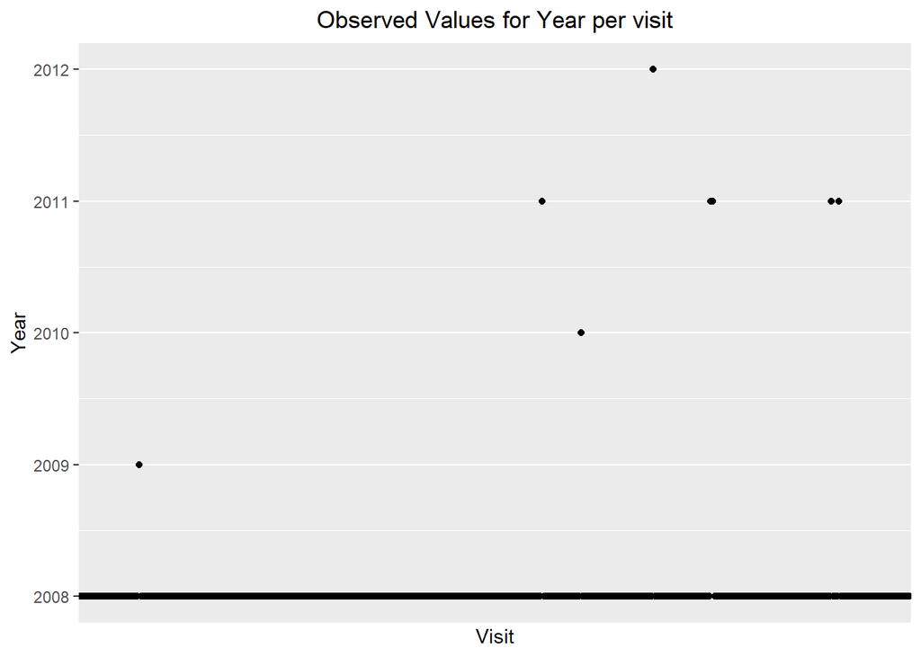

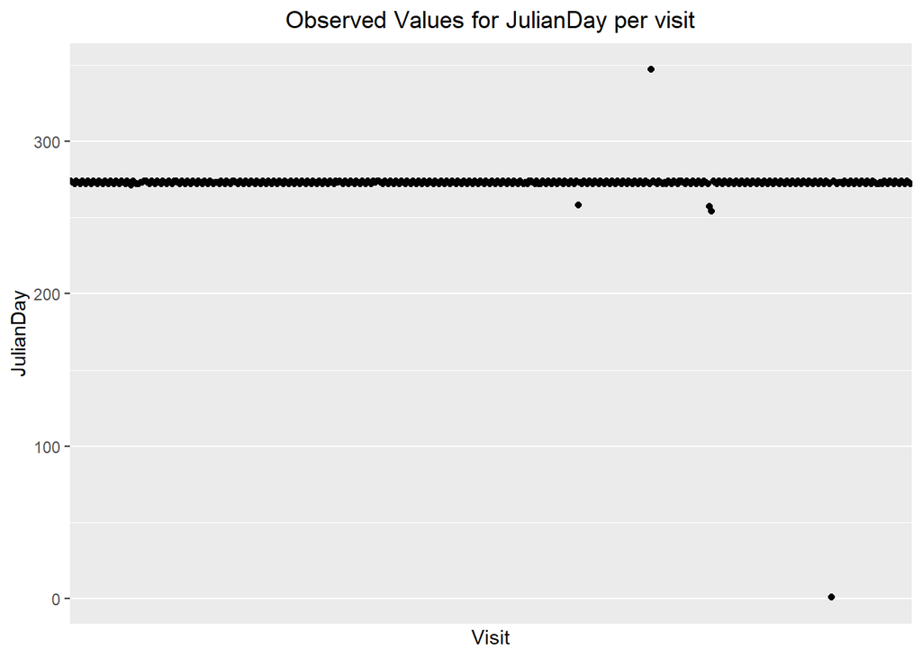

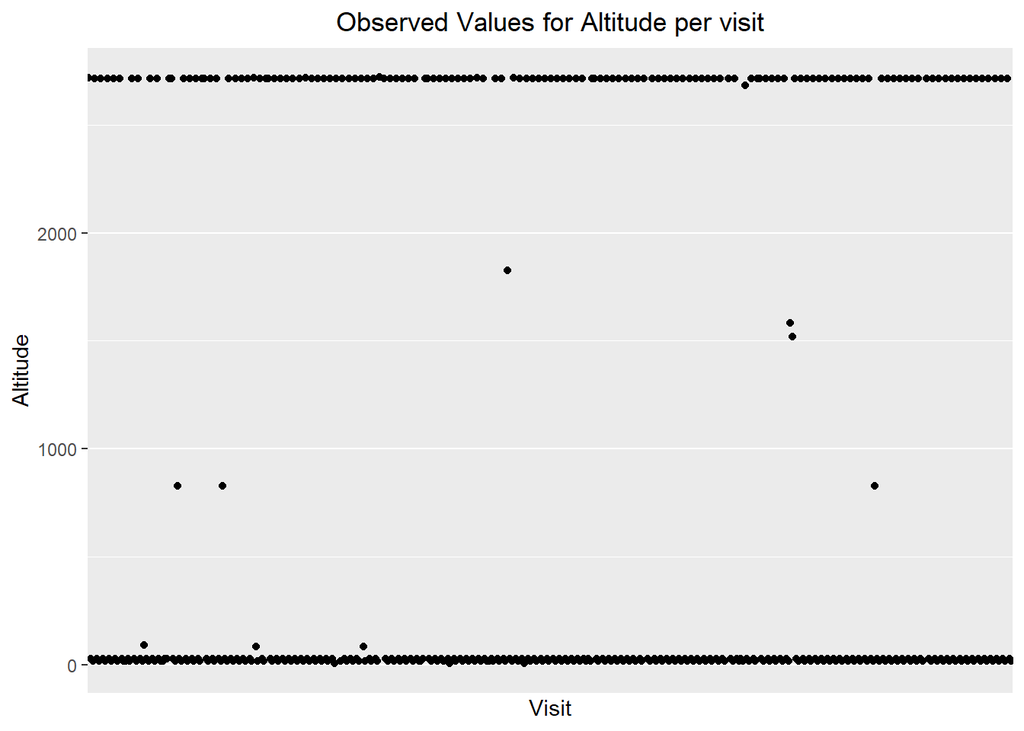

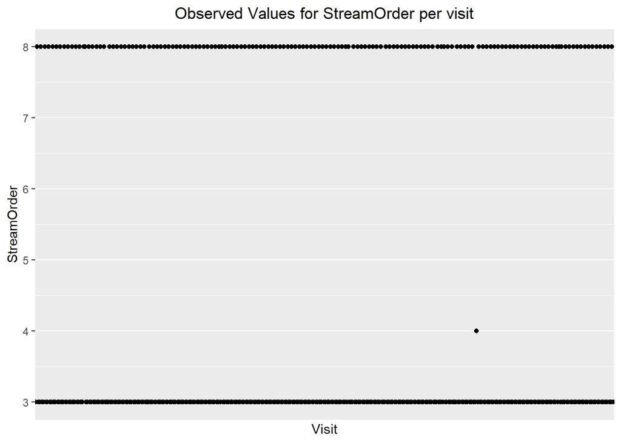

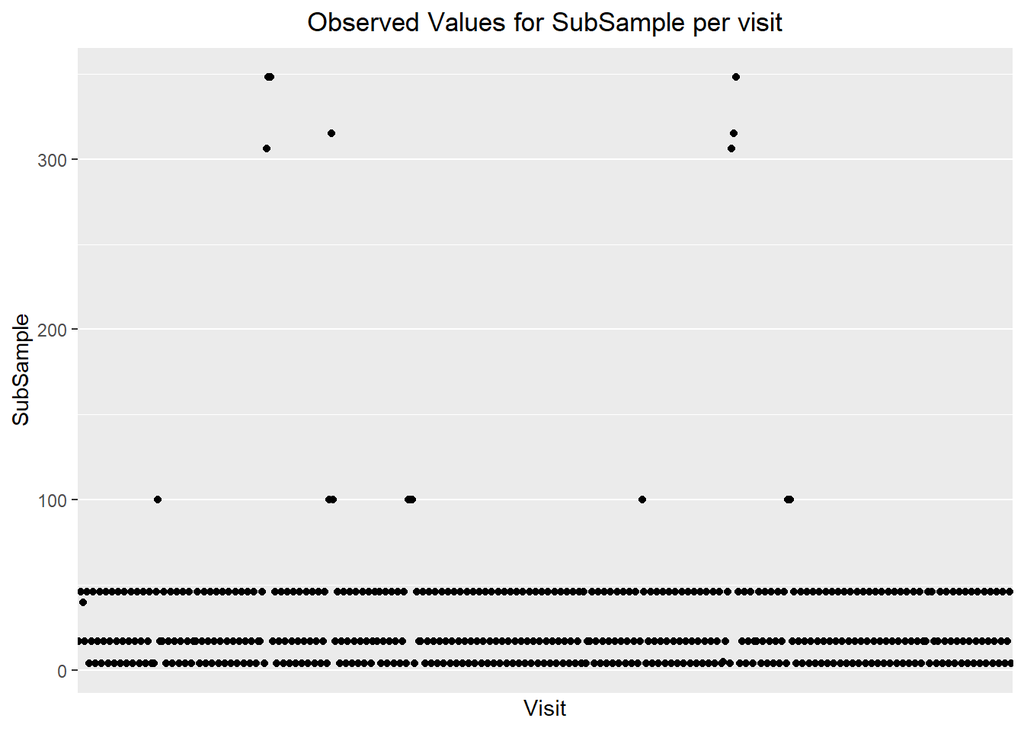

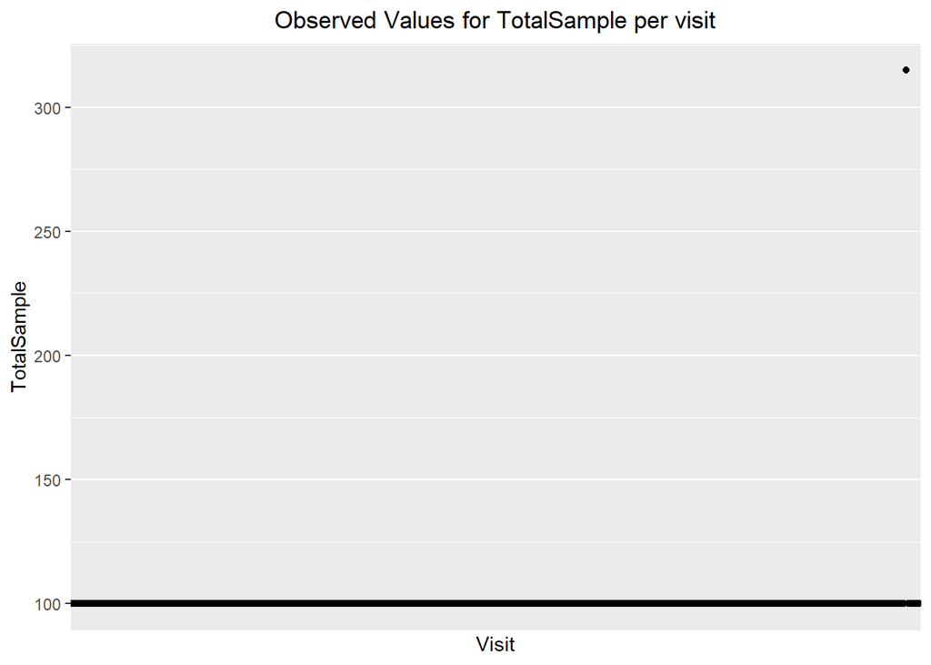

###Boxplots of Observed and Transformed Values

The first boxplot (left) shows the distribution of continuous variable values observed in the data file, and the second box plot (right) shows the distribution of the logarithmic-transformed values.

> *Check the data and make sure it reflects reality. Consider the following:*
> - *Do data seem out of the ordinary?*

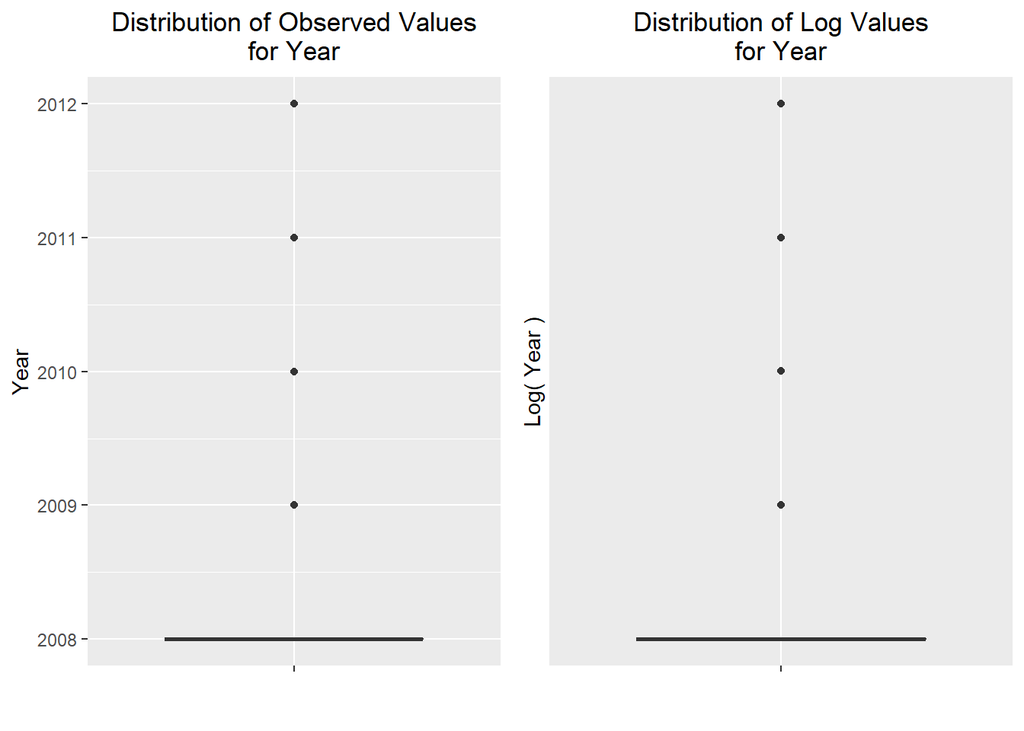

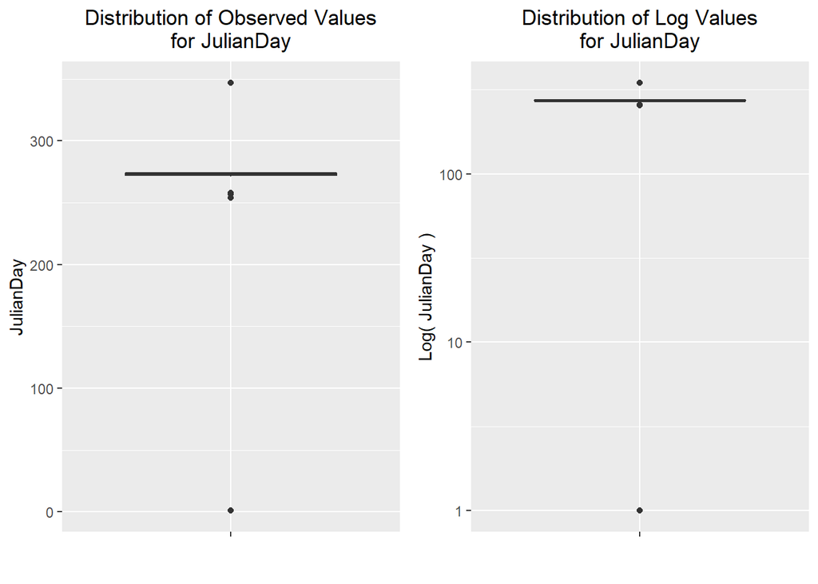

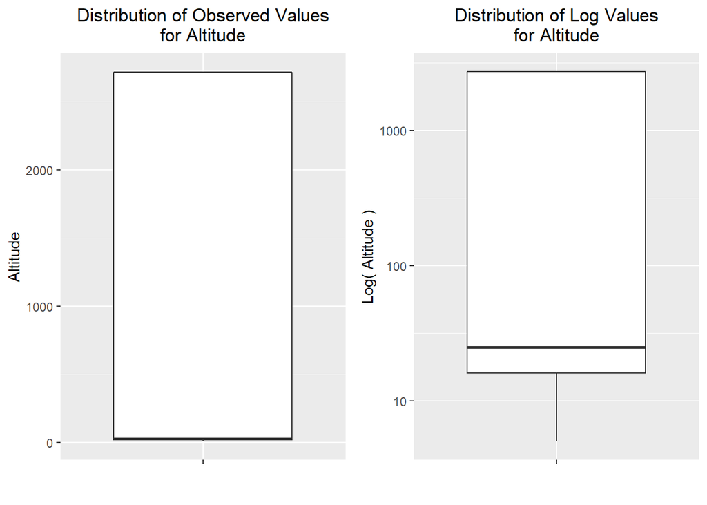

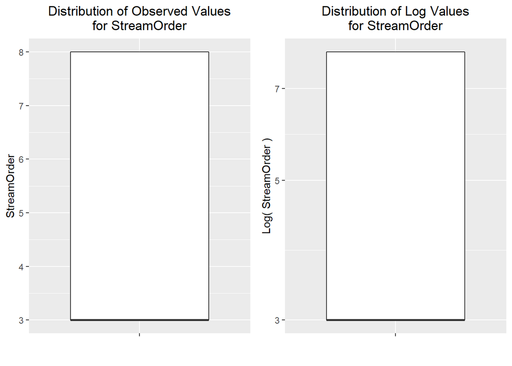

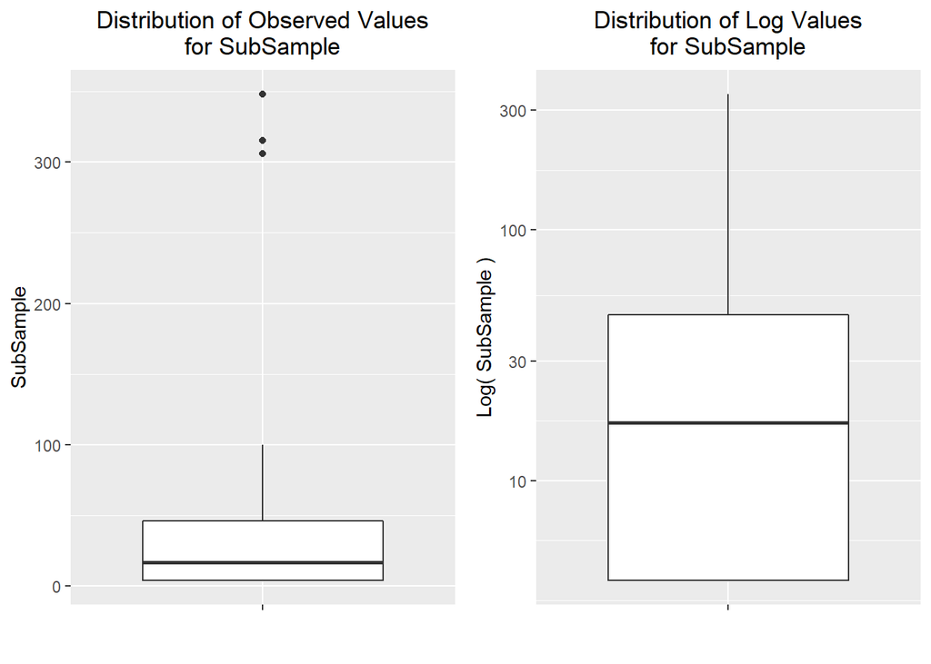

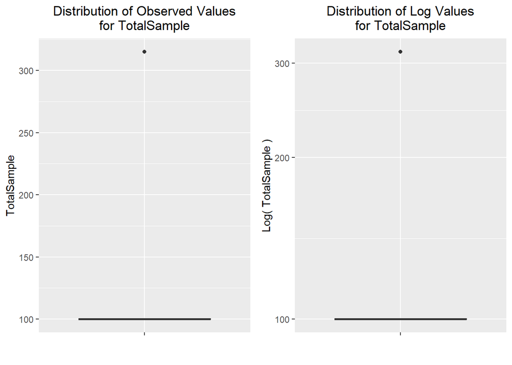

###Identification of Potential Outliers

The first boxplot (left) shows the distribution of continuous variable values observed in the dataset and the dispersion diagram (right) show the distribution of observed continuous variable values in the order in which they appear in this file. Data with identification by their identifier on the diagrams are potentially outliers contained in the dataset. The method used to identify potentially outliers is the interquantile range (*IQR*). The IQR is calculated as follows:

`IQR(x) = quantile(x, 3/4) - quantile(x, 1/4)`

Potential outliers are defined as values below *Q1 - 1,5 IQR* or above *Q3 + 1,5 IQR*.

The identifier of the visit corresponds to the name of the site from which the data originated, its sampling date and the sample number for this visit.

> *Check the following graphs and put your attention on the points with a label (if present). Consider the following:*
> - *Are potential outliers truly aberrant?*

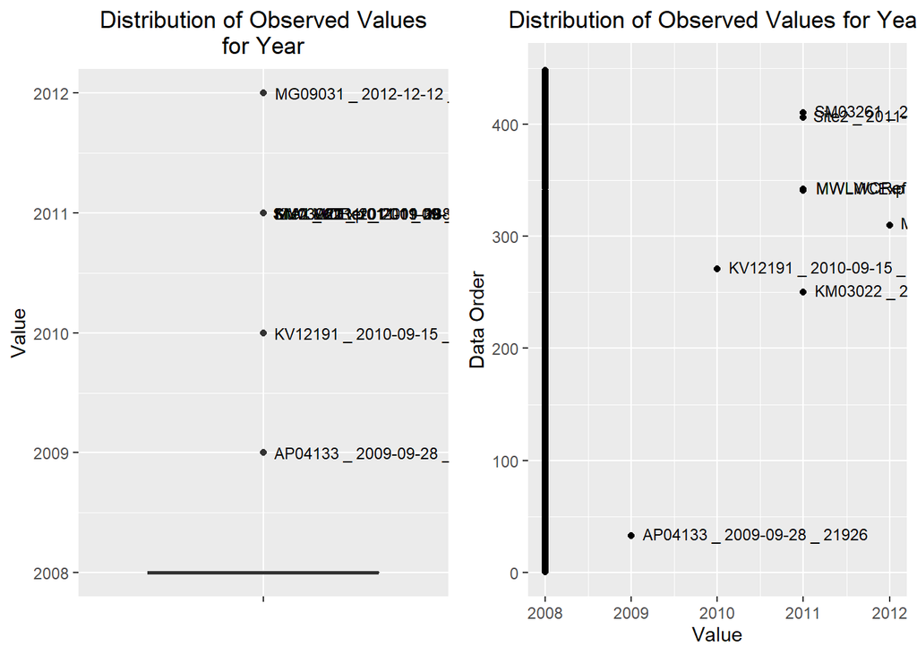

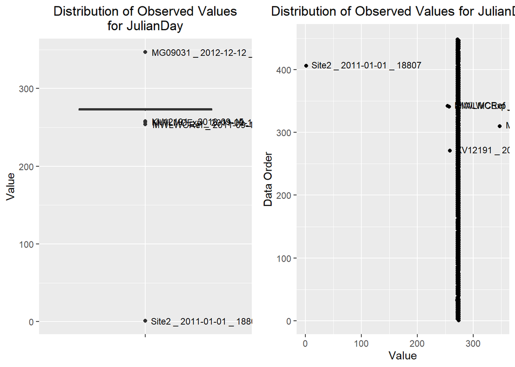

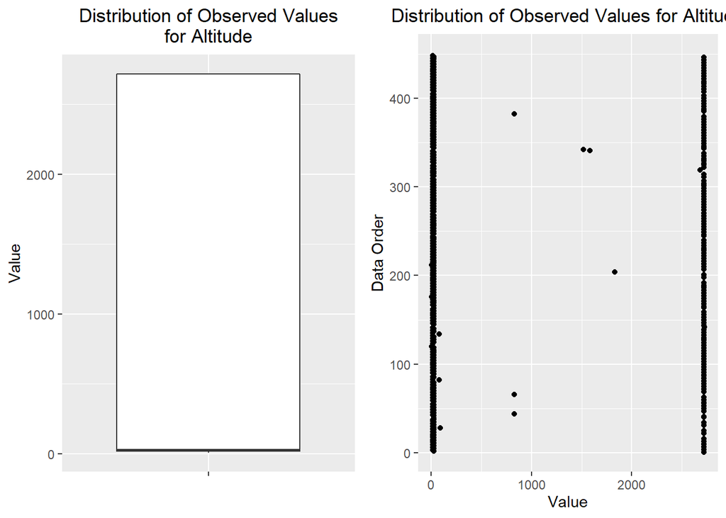

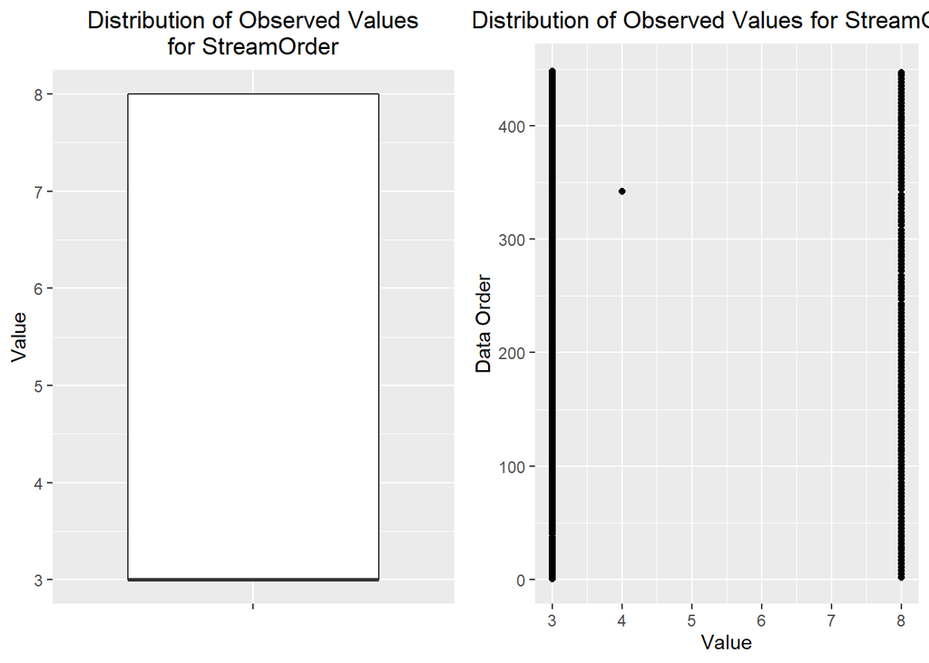

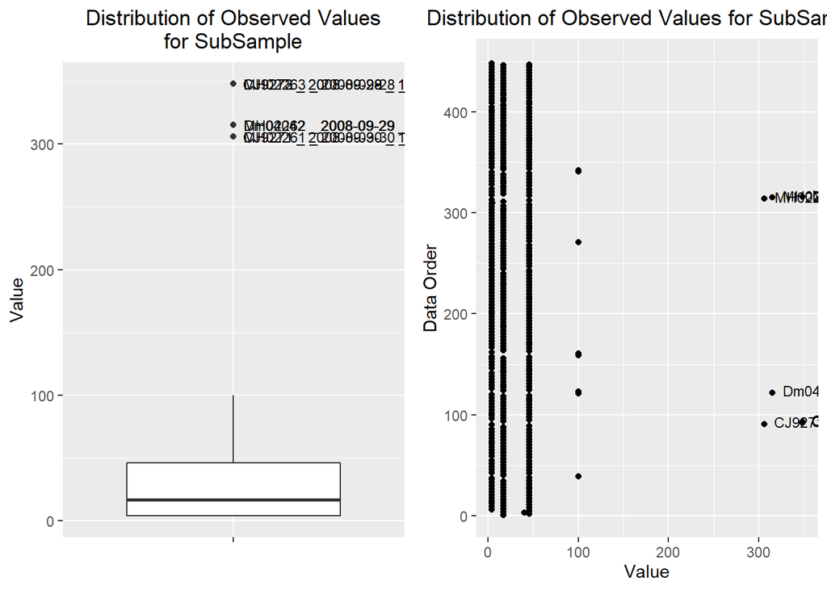

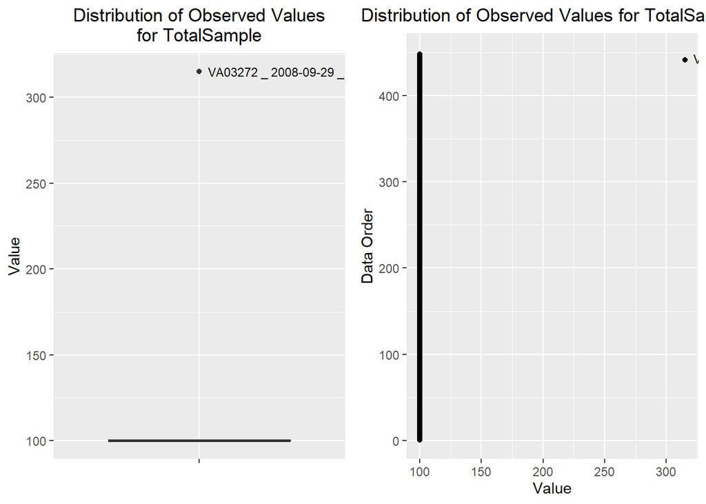

The following list shows another way of identifying potential outliers contained in the data file for each variable. When the identifier of a data item is indicated therein, this indicates that this data represents potentially aberrant data contained in the data file. *""* indicates non-aberrant data and *NA* indicates missing values. The identifier of the visit corresponds to the name of the site from which the data originated, its sampling date and the sampling number.

```
Year
Site, Date and Number, Is NA
AP04133 _ 2009-09-28 _ 21926, No
KM03022 _ 2011-09-29 _ 18658, No
KV12191 _ 2010-09-15 _ 18310, No
MG09031 _ 2012-12-12 _ 21909, No
MWLMCExp _ 2011-09-14 _ 19547, No
MWLWCRef _ 2011-09-11 _ 19548, No
Site2 _ 2011-01-01 _ 18807, No
SM03261 _ 2011-09-30 _ 19068, No
Number of Potential Outliers: 8

JulianDay
Site, Date and Number, Is NA
KV12191 _ 2010-09-15 _ 18310, No
MG09031 _ 2012-12-12 _ 21909, No
MWLMCExp _ 2011-09-14 _ 19547, No
MWLWCRef _ 2011-09-11 _ 19548, No
Site2 _ 2011-01-01 _ 18807, No
Number of Potential Outliers: 5

Altitude
Site, Date and Number, Is NA
Dm04042 _ 2008-09-29 _ 18678, Yes
EK07042 _ 2008-09-29 _ 17444, Yes
KV12191 _ 2010-09-15 _ 18310, Yes
MG09031 _ 2012-12-12 _ 21909, Yes
Site2 _ 2011-01-01 _ 18807, Yes
Number of Potential Outliers: 5

StreamOrder
Site, Date and Number, Is NA
Number of Potential Outliers: 0

SubSample
Site, Date and Number, Is NA
CJ9271 _ 2008-09-30 _ 18747, No
CJ9272 _ 2008-09-29 _ 18748, No
CJ9273 _ 2008-09-28 _ 18750, No
Dm04042 _ 2008-09-29 _ 18678, No
MH02261 _ 2008-09-30 _ 16852, No
MH02262 _ 2008-09-29 _ 16858, No
MH02263 _ 2008-09-28 _ 16859, No
Number of Potential Outliers: 7

TotalSample
Site, Date and Number, Is NA
VA03272 _ 2008-09-29 _ 18740, No
Number of Potential Outliers: 1
```

##Releases Notes **What’s New, Updated, or Fixed in This Release**

New Updated Fixed

**CABIN_vv_general.Rmd Version 1.2 — February 5, 2018**

**Outliers detection** — updated routine to identify potential outliers for all numeric variables in general data.

**CABIN_vv_general.Rmd Version 1.1 — September 22, 2017**

**Actions** — Added suggestions of actions to help in the verification and validation of general data.

**CABIN_vv_general.Rmd Version 1.0 — August 18, 2017**

**First completed version**.

Developed by Martin Jean and Evelyne Paquette-Boisclair